# Malaria Exposure and Infection

Lecture

David Smith

2022-09-07

## -

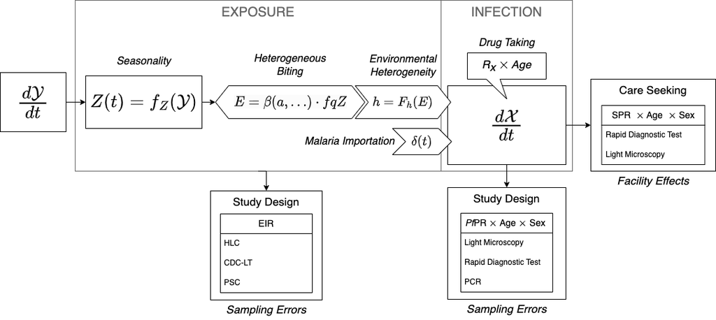

**Figure 1**: A core problem is to understand malaria transmission by mosquitoes, which requires understanding the process of exposure and infection. This diagram illustrates how the RAMP algorithms deal with the relationship.

## Outline

**Exposure vs. Infection**

- Malaria transmission is forced by adult mosquitoes through blood feeding.
- We can compute thresholds for malaria elimination:
  - Threshold density of mosquitoes
  - $R_0$ / $R_C$
- We can measure exposure through the EIR, which serves as a useful measure of transmission because
  - Vectorial capacity ($V$) is roughly the same concept as the EIR ($E$). In the Ross-Macdonald model, one is derived from the other:
    $$E(1+s\kappa) =
    V\kappa$$
  - …so in the classical $R_C = bVD \approx E (1+S\kappa) /\kappa$
  - …and $\kappa = f_\kappa(X(E))$ la
- More generally, we want to know how to weigh tradeoffs through vector control:
  - Burden in relation to exposure
  - Exposure in relation to transmission
  - Transmission effect sizes ($R_0/R_C$) in relation to coverage
  - Coverage in relation to costs
- …but the EIR is expensive to measure, so we need an estimate that is based on other metrics:
  - The TPR appears to be biased. It is probably reliable, but we don’t have paired estimates of the TPR and the EIR.
  - The PR is routinely measured in research settings, in DHS / MIS and there is a lot of PR data.

## Models & Data

### *Pf*EIR *vs.* *Pf*PR

Smith, D.L., Dushoff, J., Snow, R.W., and Hay, S.I. (2005). The entomological inoculation rate and *Plasmodium falciparum* infection in African children. Nature 438, 492–495.

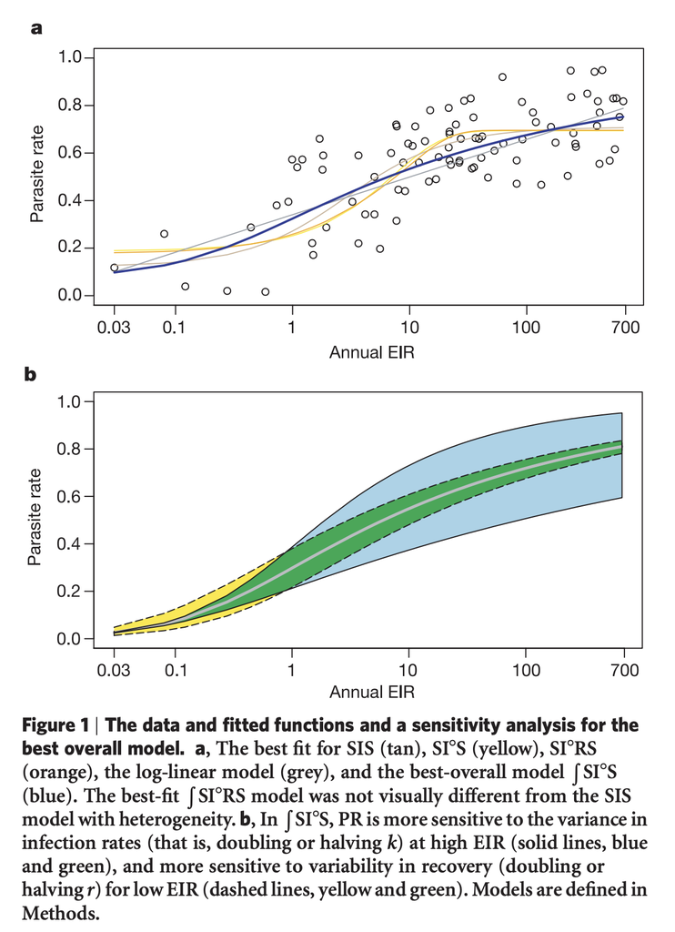

### Causes

- Heterogeneous exposure
  - Exposure $\times$ age
  - Exposure $\times$ location
  - Exposure $\times$ season
  - Individual-level Frailty
  - Negative binomial exposure
  - …
- Immunity / Reduced Susceptibility
  - Chemo-protection
  - Pre-erythrocytic immunity
  - Blood stage immunity ($\times$ age)
  - Iron Limitation
- EIR estimates are inaccurate

### Immunity

There’s an identifiability problem.

- Filion, G.J.P., Paul, R.E.L., and Robert, V. (2006). Transmission and immunity: the importance of heterogeneity in the fight against malaria. Trends Parasitol. 22, 345–348.
- Hoffman, S.L., Oster, C.N., Plowe, C.V., Woollett, G.R., Beier, J.C., Chulay, J.D., Wirtz, R.A., Hollingdale, M.R., and Mugambi, M. (1987). Naturally acquired antibodies to sporozoites do not prevent malaria: vaccine development implications. Science 237, 639–642.

### *Pf*EIR *vs.* *Pf*FoI

[figure not shown]

## Vector Control {.tabset}

### Example

After control with IRS, aEIR $\approx 1$ so $R_C \gg 40$

- Smith, D.L., Musiime, A.K., Maxwell, K., Lindsay, S.W., and Kiware, S. (2021). A New Test of a Theory about Old Mosquitoes.

[figure not shown]

## Scaling

- The Ross-Macdonald model predicts the wrong scaling relationships for control.

[figure not shown]

```r
par(mfrow = c(2,1))
aEIR = 10^seq(-1, 3, length.out=100)
dEIR = aEIR/365
r=1/200
b=0.55
br = .45
k = 1/4.2
foi1 = b*dEIR
pr1 = foi1/(r+foi1)
pr2 = 1 - (1+ br*aEIR/k)^(-k)
pr3 = .084*log(aEIR) + .32
plot(aEIR, pr1, type = "l", log="x", xaxt = "n", ylab = "PR")
lines(aEIR, pr2)
lines(aEIR, pr3)
axis(1, 10^c(-1:3), c("0.1", 1, 10, 100, 1000))
plot(aEIR, pr1, type = "l", ylab = "PR", xlim = c(0.5,20))
lines(aEIR, pr2)
lines(aEIR, pr3)
```